# ARIMA/SARIMA/ARFIMA

Hritik

2025-03-12

# Business Problem & Importance

Air pollution is a critical public health issue in urban areas, with long-term exposure leading to respiratory diseases, cardiovascular issues, and reduced life expectancy. In London, monitoring air quality is essential for policymakers, environmental agencies, and the public to make informed decisions about pollution control measures. Poor air quality can also have economic implications, affecting workforce productivity, healthcare costs, and overall city livability. By accurately forecasting air quality, authorities can implement timely interventions, issue health advisories, and plan for future improvements in environmental policies.

# Stakeholders

1. Greater London Authority (GLA) & Local Councils - Responsible for implementing air quality policies, enforcing emissions regulations, and developing environmental strategies to improve air quality across London boroughs.
2. UK Environment Agency & DEFRA (Department for Environment, Food & Rural Affairs) - Monitor air pollution levels, set national air quality standards, and provide funding for clean air initiatives.
3. Public Health England (PHE) & NHS - Assess the impact of air pollution on public health, issue health warnings, and develop strategies to mitigate health risks, particularly for vulnerable populations (children, elderly, and those with pre-existing conditions).
4. Transport for London (TfL) & Automotive Industry - Responsible for managing traffic congestion, expanding low-emission transport solutions, and implementing policies like the Ultra Low Emission Zone (ULEZ) to reduce vehicular pollution.
5. Businesses & Industrial Sectors - Particularly those in energy, construction, and manufacturing industries, which must comply with emissions regulations and adopt cleaner technologies to minimize their environmental footprint.
6. London Residents, Commuters & Environmental Advocacy Groups - Individuals affected by air pollution, including daily commuters, cyclists, and environmental activists campaigning for stricter pollution controls and sustainability initiatives.

# Forecasting Objective

The goal of this project is to develop a forecasting model for London’s Air Quality Index (AQI) based on historical data. The model will help predict future AQI levels, allowing stakeholders to:

- Issue early warnings for high pollution days by identifying peak pollution hours and locations, enabling timely public health advisories and traffic control measures.
- Implement short-term pollution control measures such as temporary traffic restrictions, increased public transport availability, and industrial activity regulation during high-risk periods.
- Develop long-term pollution mitigation strategies, including expansion of low-emission zones, increased green spaces, and stricter emission regulations for businesses and vehicles.
- Improve public health strategies by providing targeted alerts for at-risk populations (e.g., children, elderly, and those with respiratory conditions), integrating AQI forecasts into healthcare planning.
- Enhance urban planning efforts by using AQI trends to guide infrastructure development, optimize road networks to reduce congestion, and promote sustainable city designs that minimize pollution sources.

# Data Source

The dataset, “London_AQI_Daily.csv,” contains daily air quality index (USAQI) readings for London. We aquired this dataset from **www.open-meteo.com**. Open-Meteo is an open-source weather API that offers free access to weather data for non-commercial use. The data spans from January 2, 2013, to February 28, 2025, capturing long-term trends and seasonal variations.

# Description of Dataset

Size: 4,441 records (after processing)

Variables:

Date (YYYY-MM-DD) – The recorded date of the AQI measurement.

USAQI – The Air Quality Index value based on U.S. Environmental Protection Agency (EPA) standards.

This dataset provides a structured historical view of air pollution in London, which can be used for trend analysis, predictive modeling, and policy formulation.

## Setup

```r
# Load dataset
#setwd("/Users/hritikjhaveri/Desktop/UChicago/Q2/Time_Series_Analysis_Forcasting/Final_Project")
#getwd()

#df <- read.csv("London_AQI_Daily.csv")
df <- read.csv("../Data/London_AQI_Daily.csv")
# Convert 'Date' column to datetime format
df$Date <- as.Date(df$Date, format = "%Y-%m-%d")

# Ensure the data is sorted by Date
df <- df %>% arrange(Date)

# View first few rows
head(df)
```

```
##         Date USAQI
## 1 2013-01-02    36
## 2 2013-01-03    39
## 3 2013-01-04    34
## 4 2013-01-05    28
## 5 2013-01-06    38
## 6 2013-01-07    42
```

```r
# Check data types
str(df)
```

```
## 'data.frame':    4441 obs. of  2 variables:
##  $ Date : Date, format: "2013-01-02" "2013-01-03" ...
##  $ USAQI: int  36 39 34 28 38 42 56 54 29 22 ...
```

```r
# Check for missing values
sum(is.na(df))
```

```
## [1] 0
```

```r
# Summary stats for AQI
summary(df$USAQI)
```

```
##    Min. 1st Qu.  Median    Mean 3rd Qu.    Max.
##   17.00   33.00   43.00   47.44   58.00  155.00
```

## Data Preparation and Transformations

```r
# Ensure ts_data is a daily time series object
ts_data <- ts(df$USAQI, start = c(2013, 1, 2), frequency = 365)  # Adjust for leap years if necessary

# Apply transformations to the entire dataset
transformed_data <- list(
  "1st_diff" = diff(ts_data, differences = 1),
  "diff_boxcox" = diff(BoxCox(ts_data, lambda = BoxCox.lambda(ts_data)), differences = 1),
  "seasonal_diff" = diff(ts_data, lag = 365)
)

# Split data into train and test sets
train <- window(ts_data, end = c(2024, 367))
test <- window(ts_data, start = c(2025, 3))
```

## ACF and PACF Plots

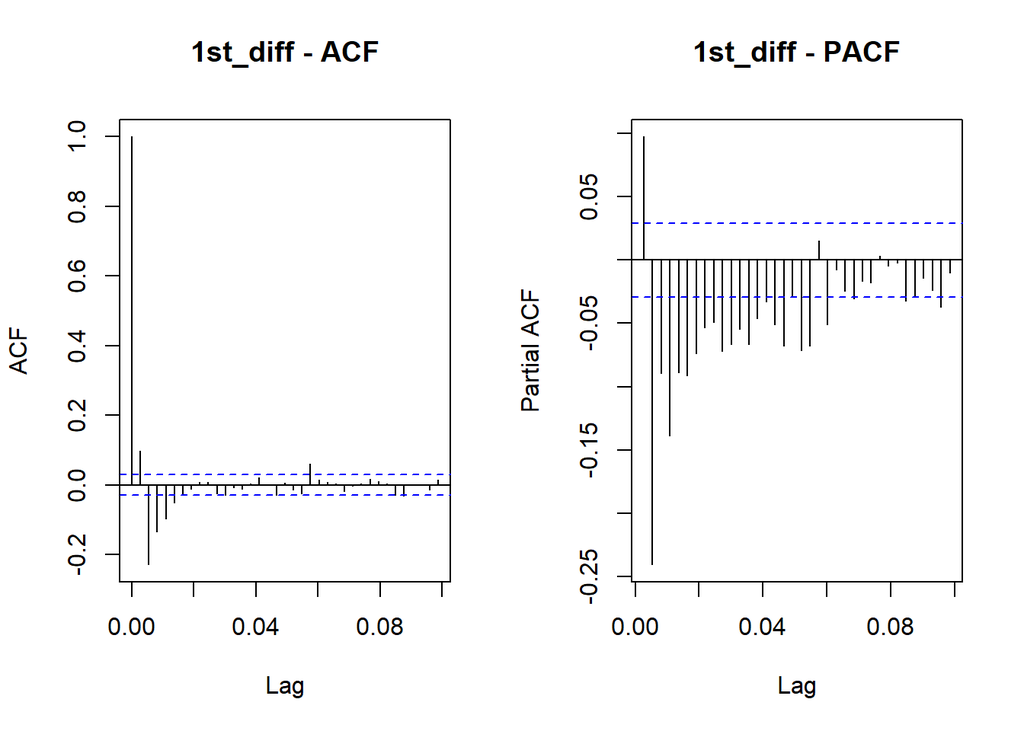

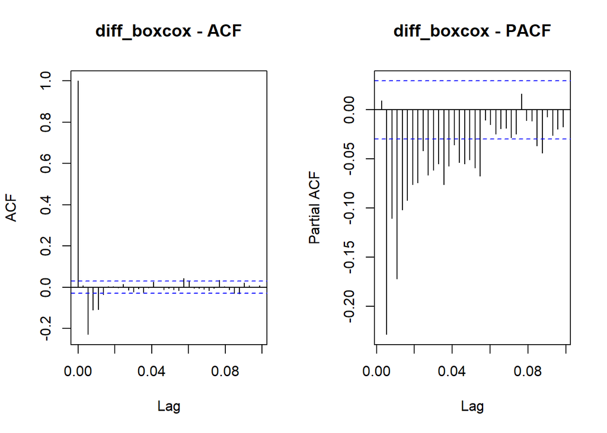

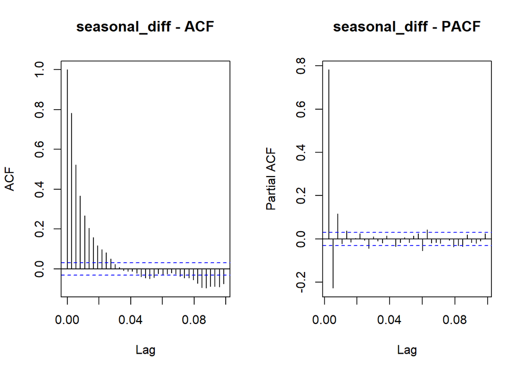

## Model Fitting and Diagnostics

```r
# Initialize results list
results <- list()

# Fit models to each transformed series
for (name in names(transformed_data)) {
  train_series <- window(transformed_data[[name]], end = c(2024, 367))

  # ARIMA Model
  arima_model <- auto.arima(train_series)
  results[[paste0(name, "_ARIMA")]] <- arima_model

  # SARIMA Model
  sarima_model <- auto.arima(train_series, seasonal = TRUE)
  results[[paste0(name, "_SARIMA")]] <- sarima_model

  # ARFIMA Model
  arfima_model <- arfima(train_series)
  results[[paste0(name, "_ARFIMA")]] <- arfima_model
}
```

## Residuals Diagnostics

```
## [1] "Diagnostics for 1st_diff_ARIMA"
```

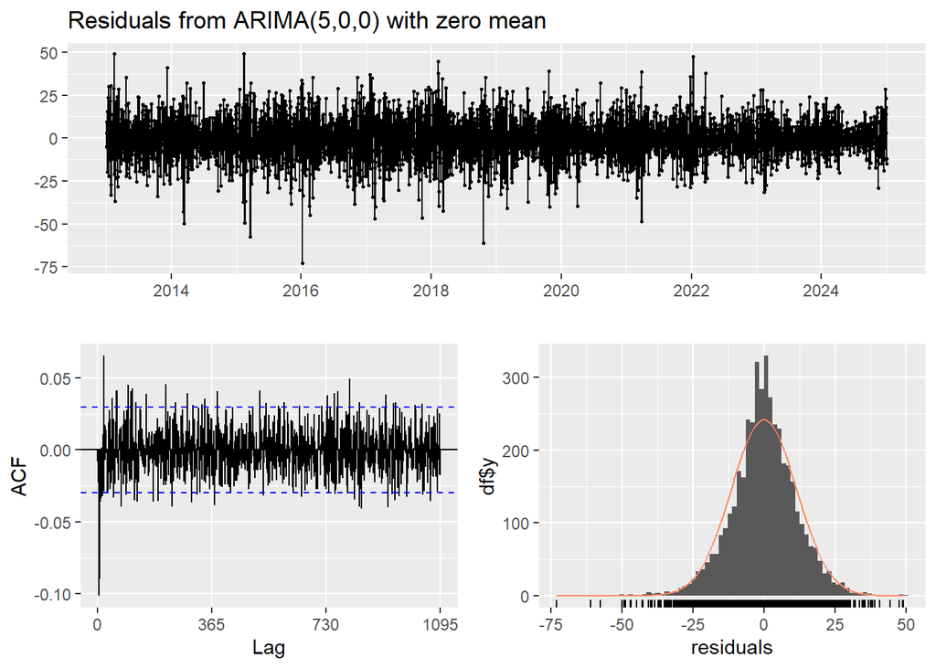

```
##
##  Ljung-Box test
##
## data:  Residuals from ARIMA(5,0,0) with zero mean
## Q* = 980.04, df = 725, p-value = 6.832e-10
##
## Model df: 5.   Total lags used: 730
```

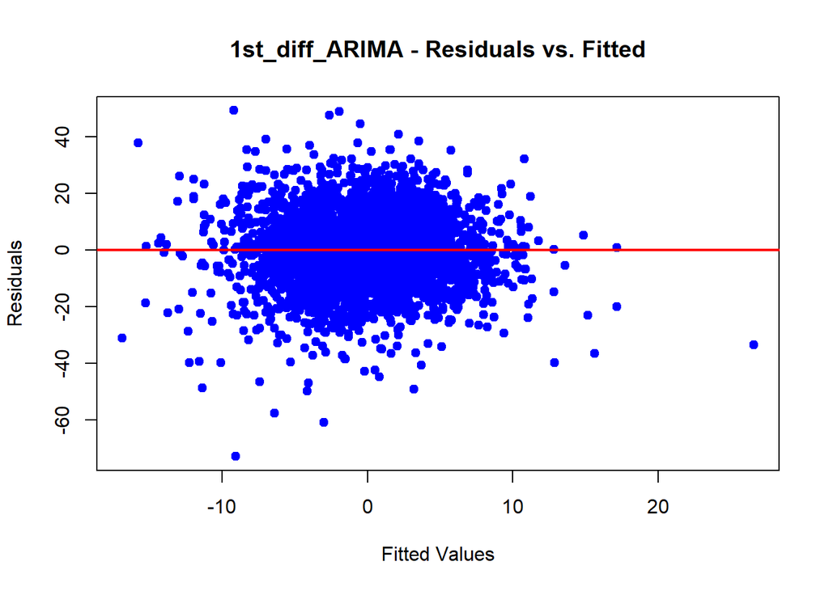

```
## [1] "Diagnostics for 1st_diff_SARIMA"
```

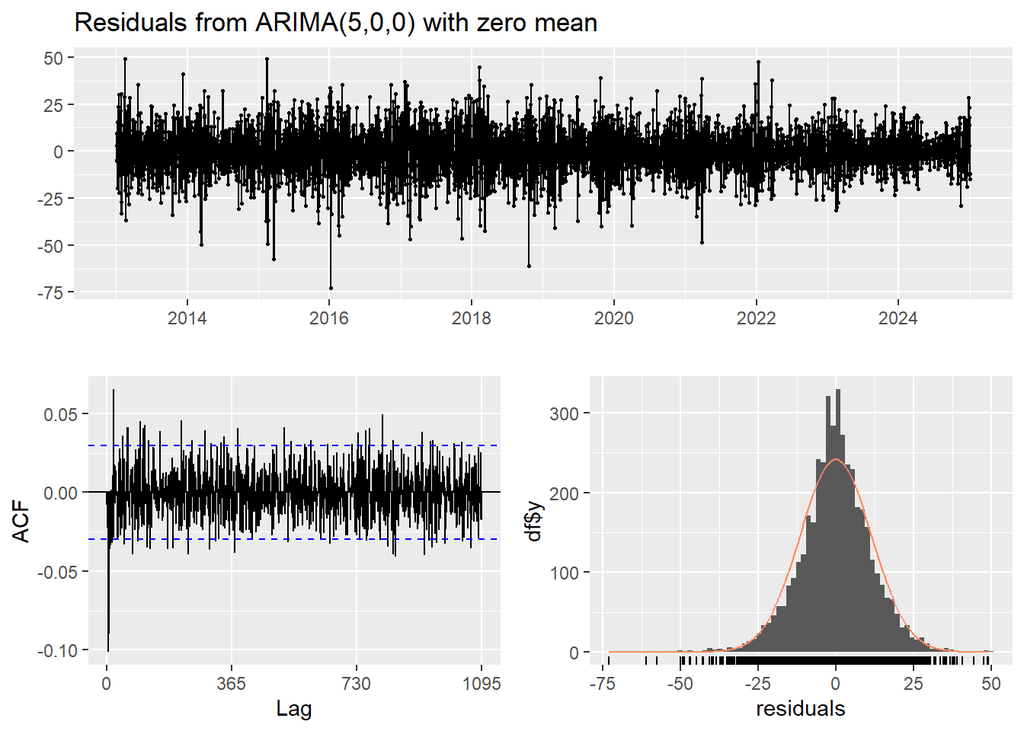

```
##
##  Ljung-Box test
##
## data:  Residuals from ARIMA(5,0,0) with zero mean
## Q* = 980.04, df = 725, p-value = 6.832e-10
##
## Model df: 5.   Total lags used: 730
```

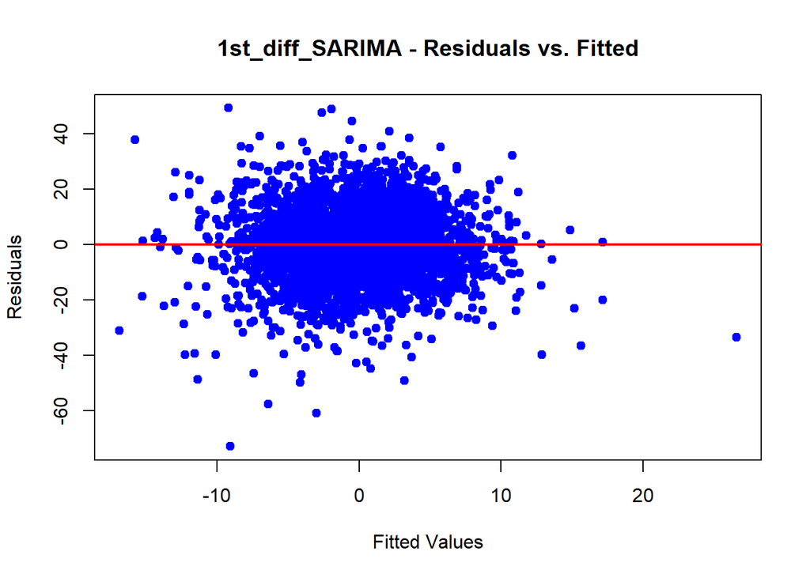

```
## [1] "Diagnostics for 1st_diff_ARFIMA"
```

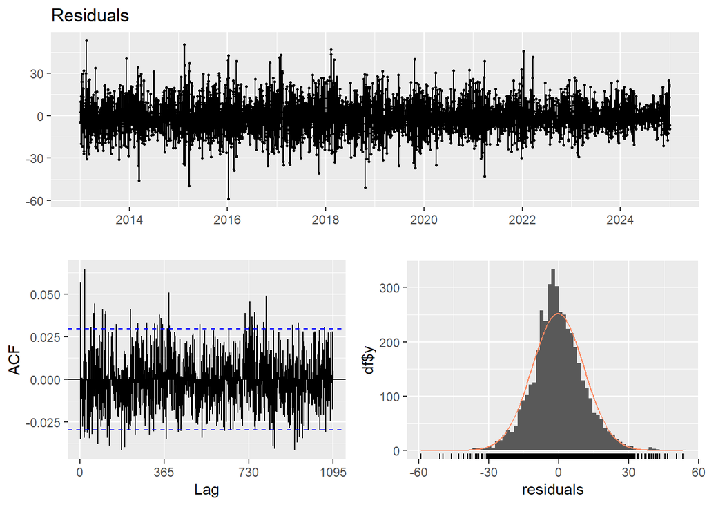

```
##
##  Ljung-Box test
##
## data:  Residuals
## Q* = 899.61, df = 730, p-value = 1.646e-05
##
## Model df: 0.   Total lags used: 730
```

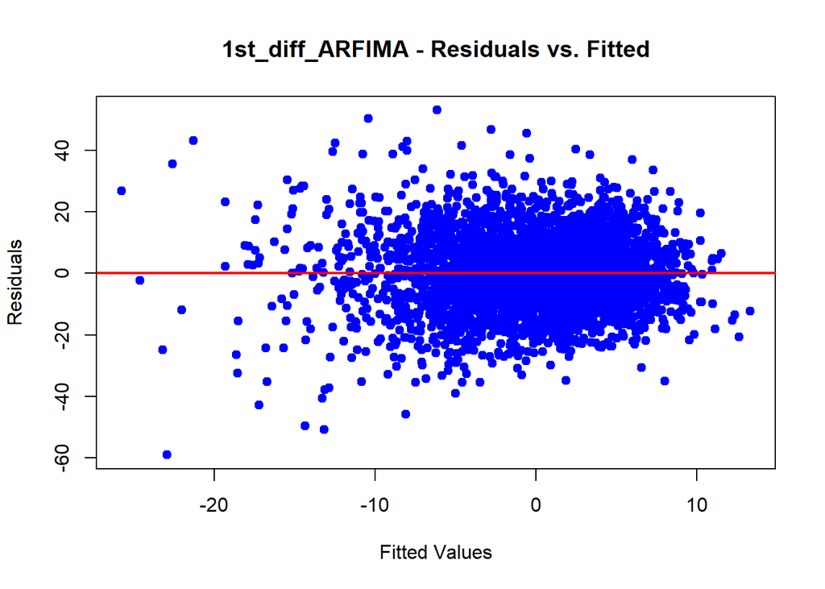

```
## [1] "Diagnostics for diff_boxcox_ARIMA"
```

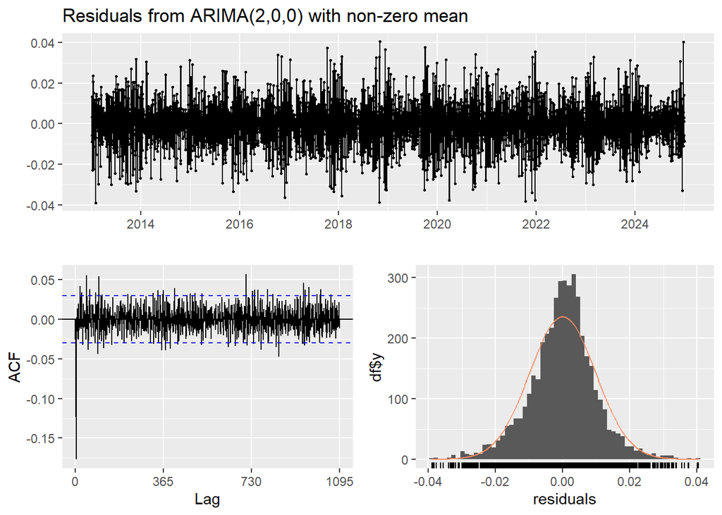

```
##
##  Ljung-Box test
##
## data:  Residuals from ARIMA(2,0,0) with non-zero mean
## Q* = 1043.6, df = 728, p-value = 1.182e-13
##
## Model df: 2.   Total lags used: 730
```

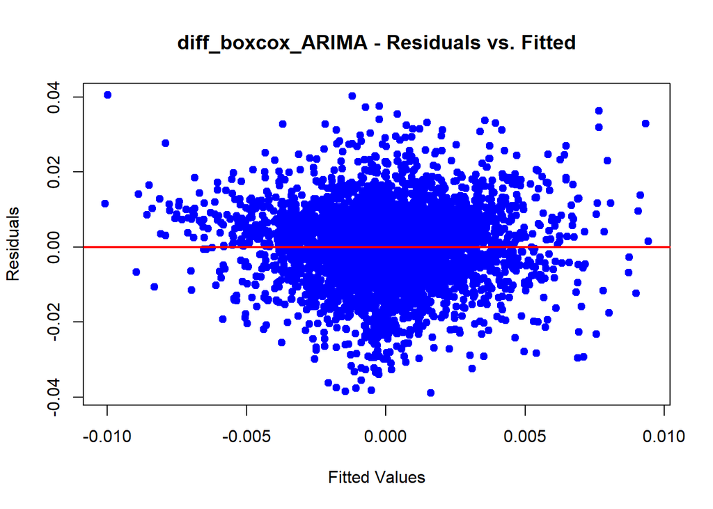

```
## [1] "Diagnostics for diff_boxcox_SARIMA"
```

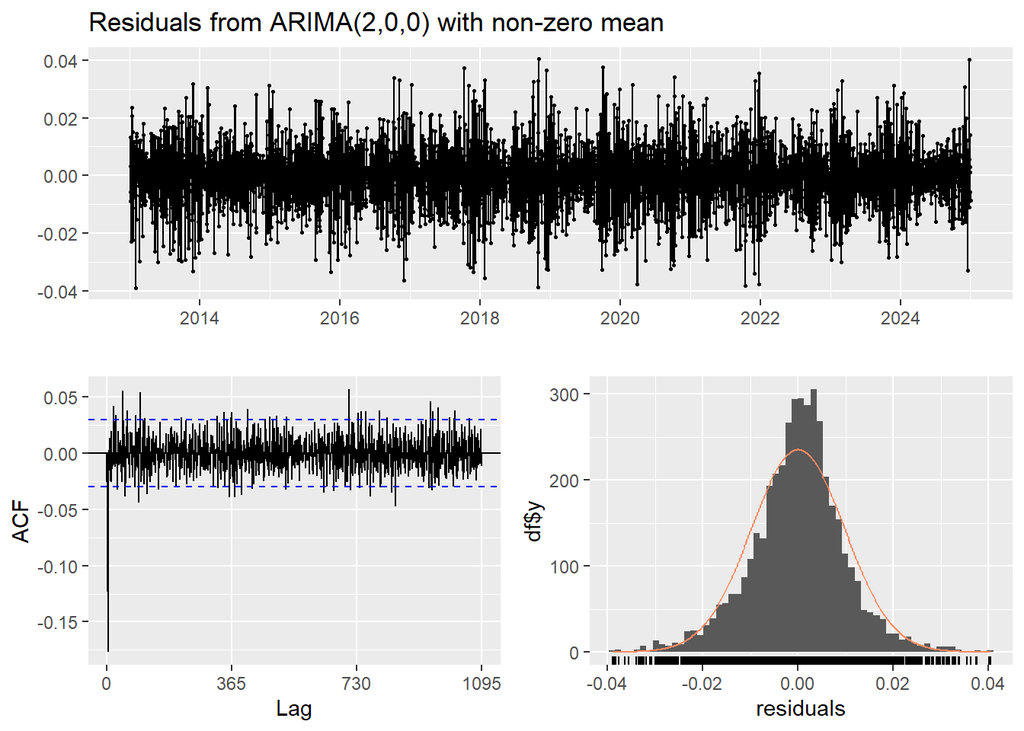

```
##
##  Ljung-Box test
##
## data:  Residuals from ARIMA(2,0,0) with non-zero mean
## Q* = 1043.6, df = 728, p-value = 1.182e-13
##
## Model df: 2.   Total lags used: 730
```

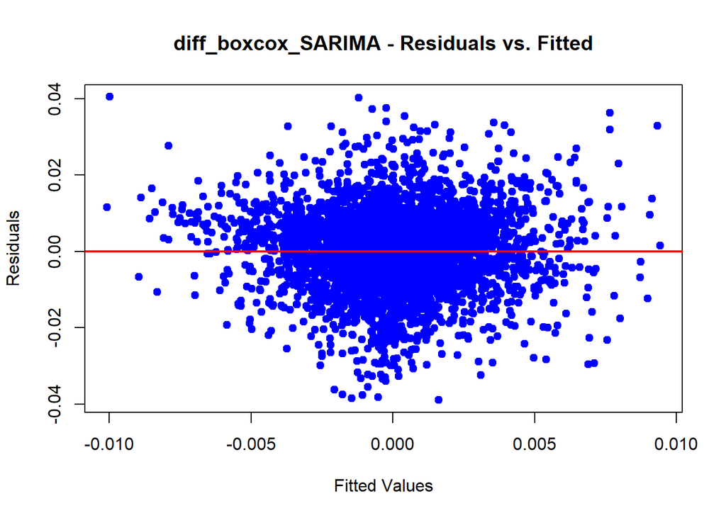

```
## [1] "Diagnostics for diff_boxcox_ARFIMA"
```

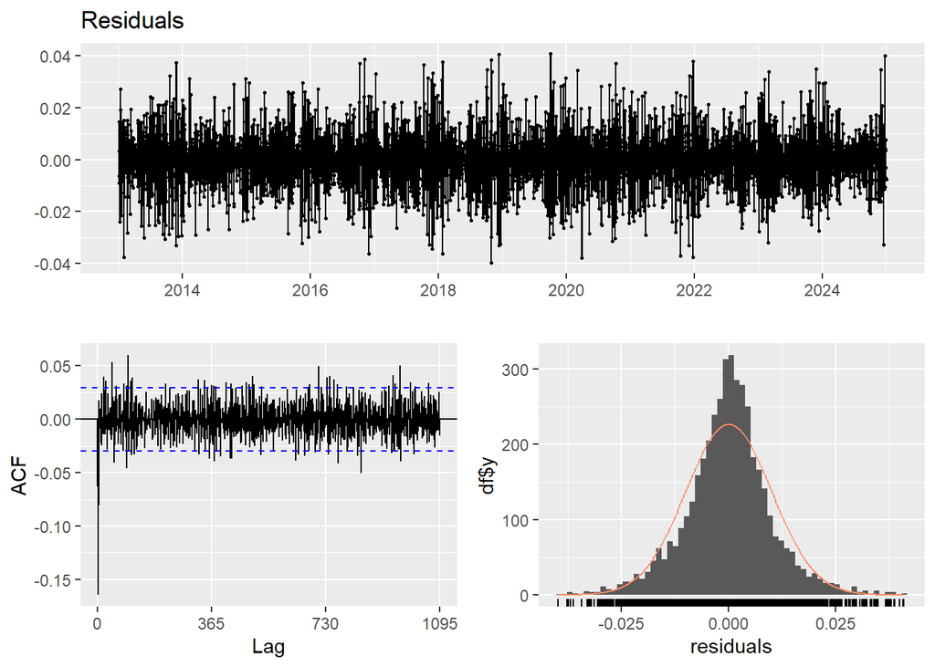

```
##
##  Ljung-Box test
##
## data:  Residuals
## Q* = 1090.8, df = 730, p-value < 2.2e-16
##
## Model df: 0.   Total lags used: 730
```

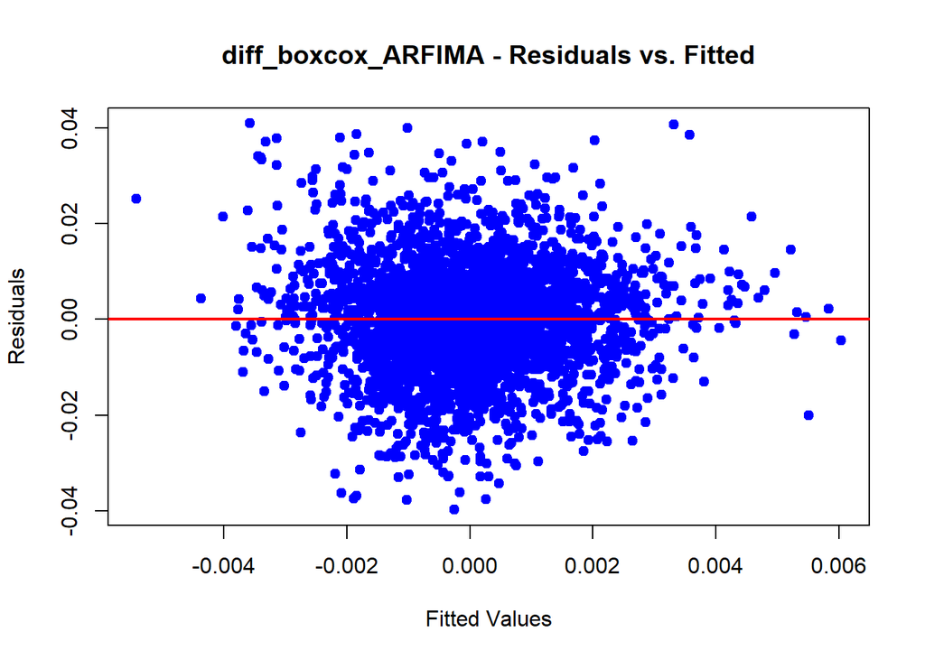

```
## [1] "Diagnostics for seasonal_diff_ARIMA"
```

[6 more figures not shown]

```r
for (name in names(transformed_data)) {
  for (model_type in c("ARIMA", "SARIMA", "ARFIMA")) {
    model_name <- paste0(name, "_", model_type)
    print(paste("Diagnostics for", model_name))
    checkresiduals(results[[model_name]])

    # Residuals vs. Fitted Plot
    plot(results[[model_name]][["fitted"]], results[[model_name]][["residuals"]],
         main = paste(model_name, "- Residuals vs. Fitted"),
         xlab = "Fitted Values", ylab = "Residuals",
         col = "blue", pch = 19)
    abline(h = 0, col = "red", lwd = 2)
  }
}
```

## ADF and KPSS Tests

```r
for (name in names(transformed_data)) {
  for (model_type in c("ARIMA", "SARIMA", "ARFIMA")) {
    model_name <- paste0(name, "_", model_type)
    print(paste("Diagnostics for", model_name))
    print(adf.test(residuals(results[[model_name]])))
    print(kpss.test(residuals(results[[model_name]])))
  }
}
```

```
## [1] "Diagnostics for 1st_diff_ARIMA"
```

```
##
##  Augmented Dickey-Fuller Test
##
## data:  residuals(results[[model_name]])
## Dickey-Fuller = -23.968, Lag order = 16, p-value = 0.01
## alternative hypothesis: stationary
```

```
##
##  KPSS Test for Level Stationarity
##
## data:  residuals(results[[model_name]])
## KPSS Level = 0.0023505, Truncation lag parameter = 10, p-value = 0.1
##
## [1] "Diagnostics for 1st_diff_SARIMA"
```

```
##
##  Augmented Dickey-Fuller Test
##
## data:  residuals(results[[model_name]])
## Dickey-Fuller = -23.968, Lag order = 16, p-value = 0.01
## alternative hypothesis: stationary
```

```
##
##  KPSS Test for Level Stationarity
##
## data:  residuals(results[[model_name]])
## KPSS Level = 0.0023505, Truncation lag parameter = 10, p-value = 0.1
##
## [1] "Diagnostics for 1st_diff_ARFIMA"
```

```
##
##  Augmented Dickey-Fuller Test
##
## data:  residuals(results[[model_name]])
## Dickey-Fuller = -17.461, Lag order = 16, p-value = 0.01
## alternative hypothesis: stationary
```

```
##
##  KPSS Test for Level Stationarity
##
## data:  residuals(results[[model_name]])
## KPSS Level = 0.019249, Truncation lag parameter = 10, p-value = 0.1
##
## [1] "Diagnostics for diff_boxcox_ARIMA"
```

```
##
##  Augmented Dickey-Fuller Test
##
## data:  residuals(results[[model_name]])
## Dickey-Fuller = -24.732, Lag order = 16, p-value = 0.01
## alternative hypothesis: stationary
```

```
##
##  KPSS Test for Level Stationarity
##
## data:  residuals(results[[model_name]])
## KPSS Level = 0.0018048, Truncation lag parameter = 10, p-value = 0.1
##
## [1] "Diagnostics for diff_boxcox_SARIMA"
```

```
##
##  Augmented Dickey-Fuller Test
##
## data:  residuals(results[[model_name]])
## Dickey-Fuller = -24.732, Lag order = 16, p-value = 0.01
## alternative hypothesis: stationary
```

```
##
##  KPSS Test for Level Stationarity
##
## data:  residuals(results[[model_name]])
## KPSS Level = 0.0018048, Truncation lag parameter = 10, p-value = 0.1
##
## [1] "Diagnostics for diff_boxcox_ARFIMA"
```

```
##
##  Augmented Dickey-Fuller Test
##
## data:  residuals(results[[model_name]])
## Dickey-Fuller = -24.975, Lag order = 16, p-value = 0.01
## alternative hypothesis: stationary
```

```
##
##  KPSS Test for Level Stationarity
##
## data:  residuals(results[[model_name]])
## KPSS Level = 0.0016047, Truncation lag parameter = 10, p-value = 0.1
##
## [1] "Diagnostics for seasonal_diff_ARIMA"
```

```
##
##  Augmented Dickey-Fuller Test
##
## data:  residuals(results[[model_name]])
## Dickey-Fuller = -15.818, Lag order = 15, p-value = 0.01
## alternative hypothesis: stationary
```

```
##
##  KPSS Test for Level Stationarity
##
## data:  residuals(results[[model_name]])
## KPSS Level = 0.22039, Truncation lag parameter = 10, p-value = 0.1
##
## [1] "Diagnostics for seasonal_diff_SARIMA"
```

```
##
##  Augmented Dickey-Fuller Test
##
## data:  residuals(results[[model_name]])
## Dickey-Fuller = -15.818, Lag order = 15, p-value = 0.01
## alternative hypothesis: stationary
```

```
##
##  KPSS Test for Level Stationarity
##
## data:  residuals(results[[model_name]])
## KPSS Level = 0.22039, Truncation lag parameter = 10, p-value = 0.1
##
## [1] "Diagnostics for seasonal_diff_ARFIMA"
```

```
##
##  Augmented Dickey-Fuller Test
##
## data:  residuals(results[[model_name]])
## Dickey-Fuller = -15.393, Lag order = 15, p-value = 0.01
## alternative hypothesis: stationary
```

```
##
##  KPSS Test for Level Stationarity
##
## data:  residuals(results[[model_name]])
## KPSS Level = 0.24379, Truncation lag parameter = 10, p-value = 0.1
```

## Forecasting and Visualization

## Forecast Plots

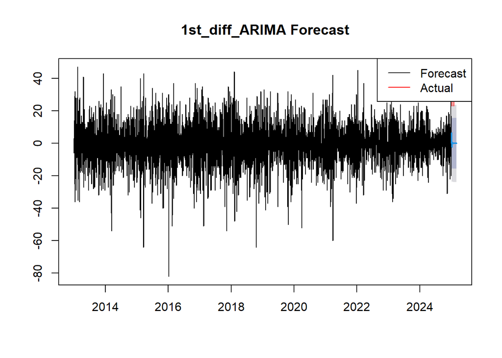

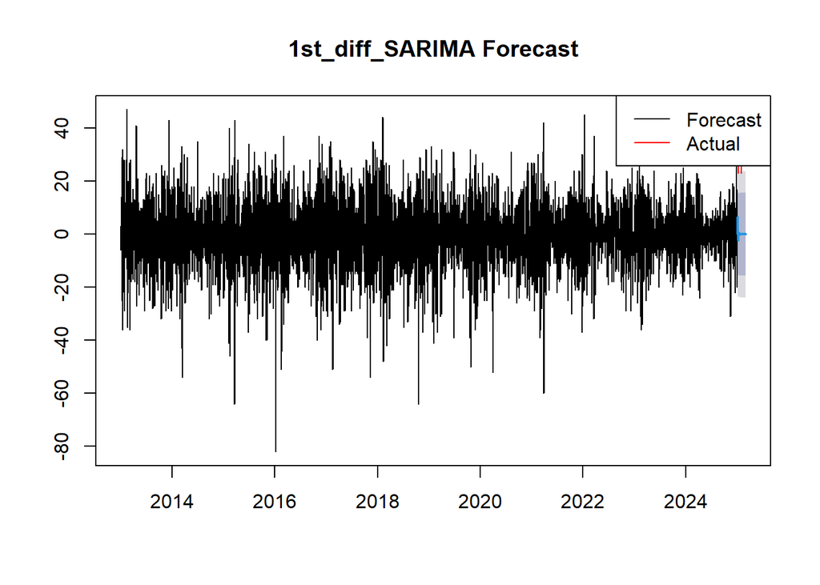

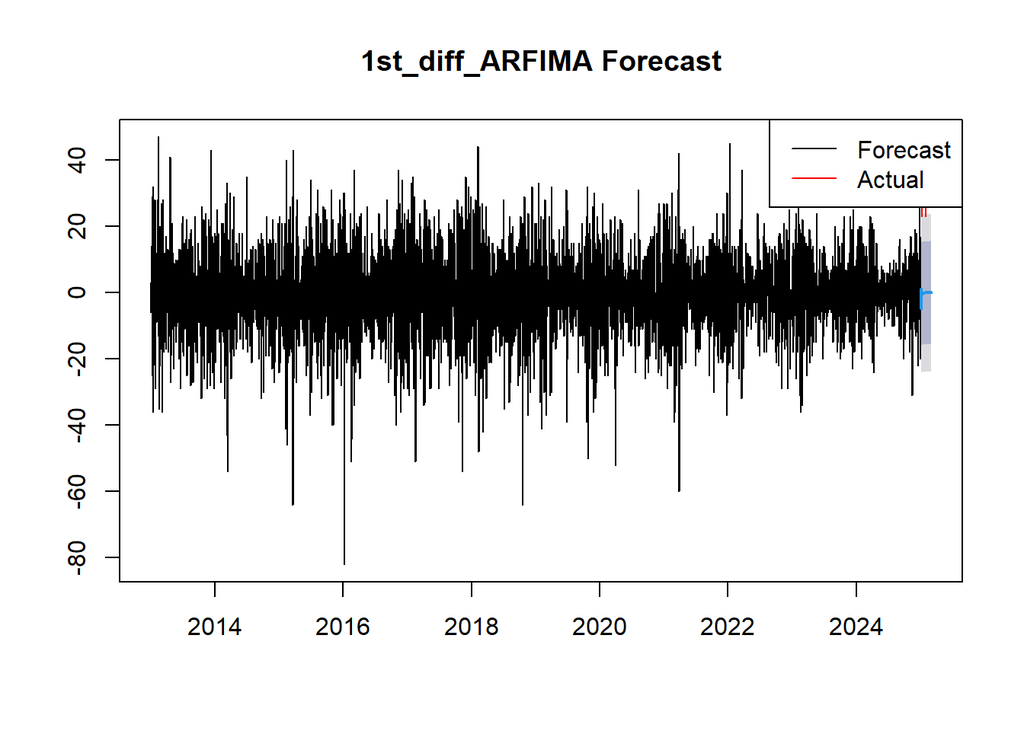

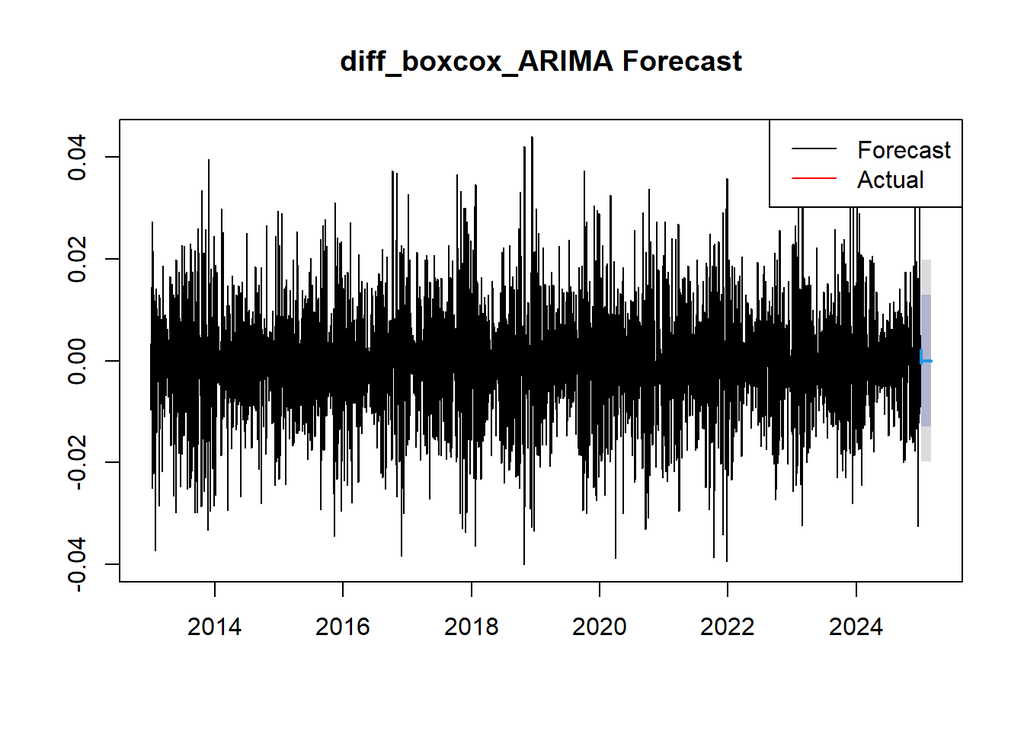

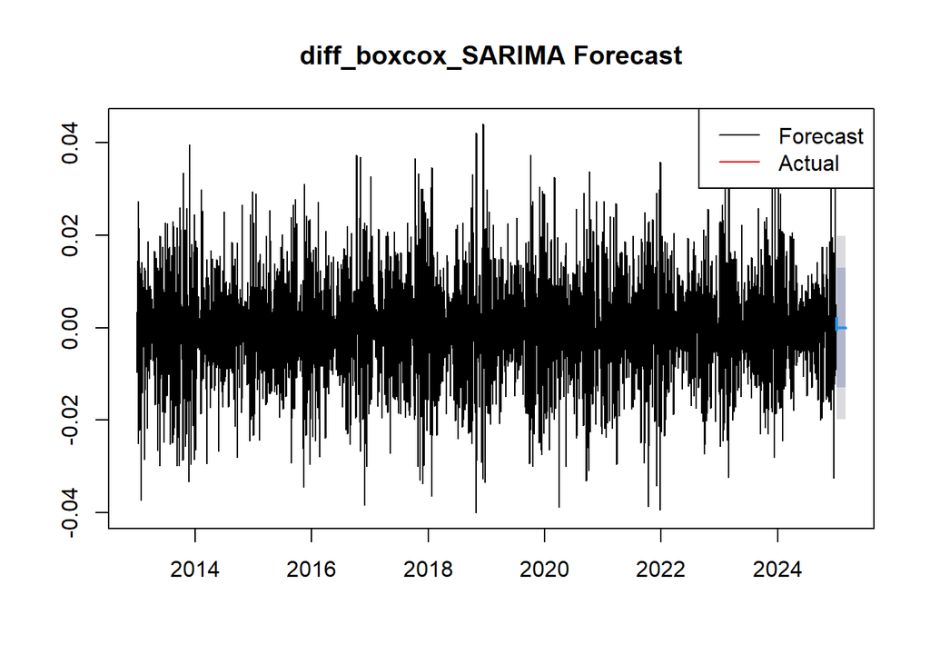

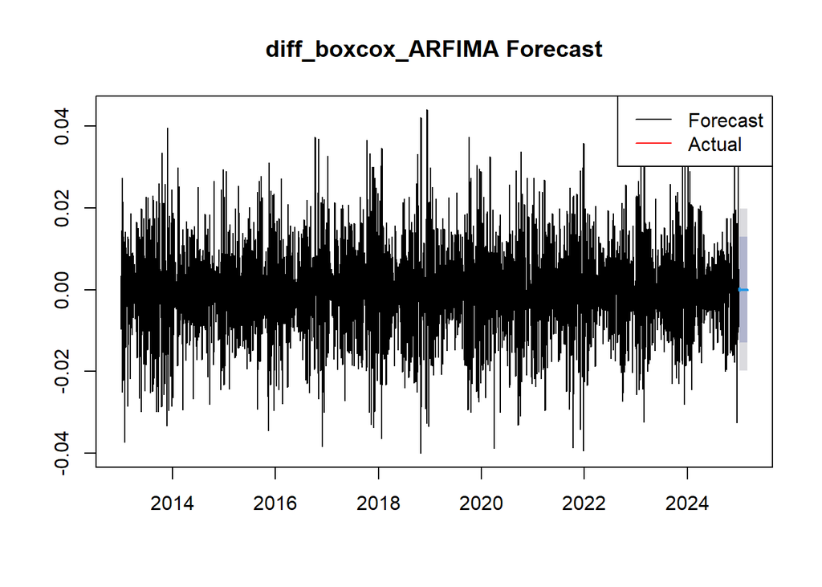

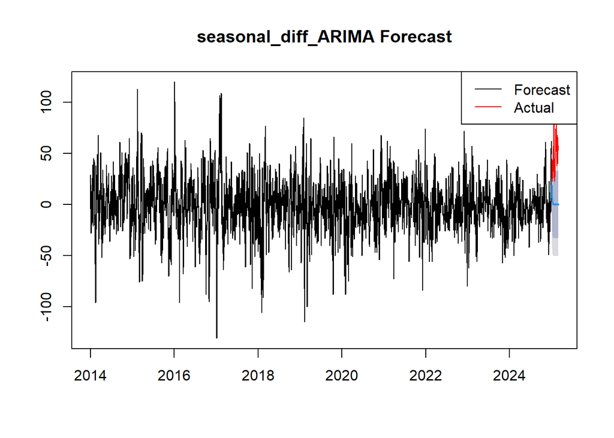

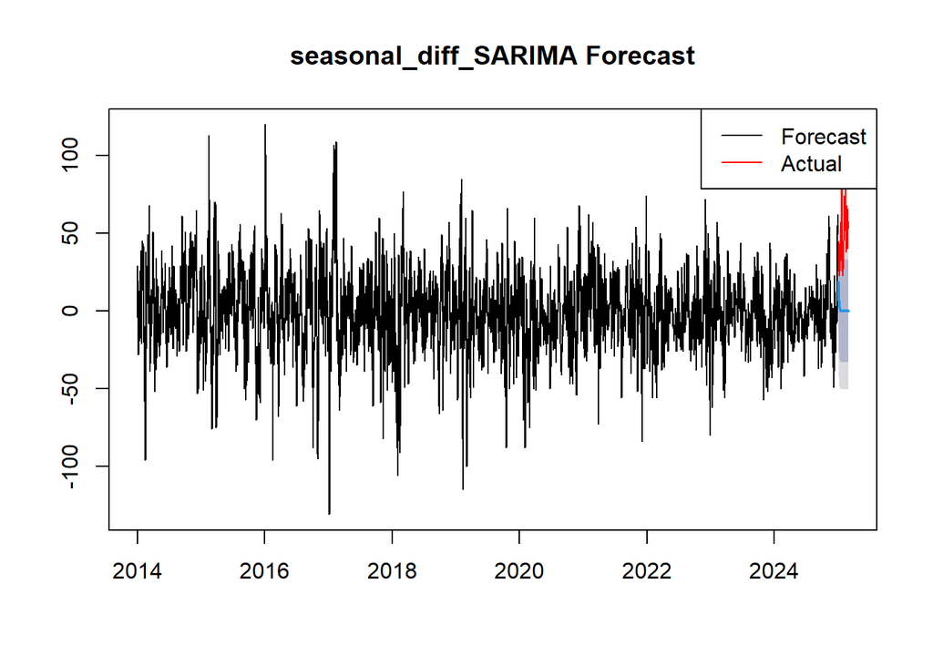

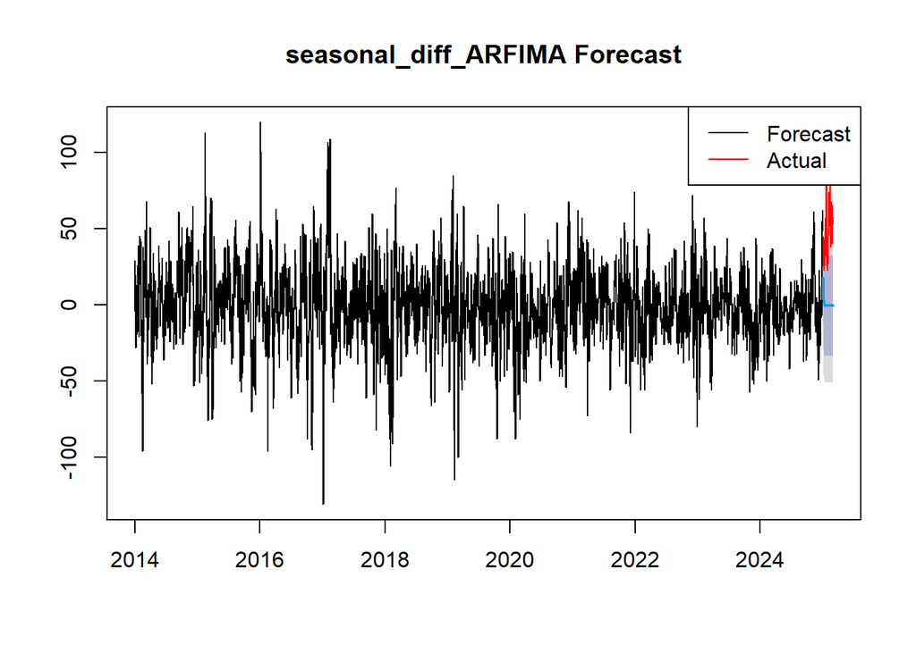

```r
for (model_name in names(forecasts)) {
  print(model_name)
}
```

```
## [1] "1st_diff_ARIMA"
## [1] "1st_diff_SARIMA"
## [1] "1st_diff_ARFIMA"
## [1] "diff_boxcox_ARIMA"
## [1] "diff_boxcox_SARIMA"
## [1] "diff_boxcox_ARFIMA"
## [1] "seasonal_diff_ARIMA"
## [1] "seasonal_diff_SARIMA"
## [1] "seasonal_diff_ARFIMA"
```

```r
# reverse differencing and box-cox
#lambda_value = BoxCox.lambda(aqi_train_ts)
#forecast_values_bc = cumsum(c(tail(train_data$USAQI, 1), dbc_for$mean))[-1]
# forecast_values_real <- inv_boxcox(forecast_values_bc, lambda = lambda_value)
# have to shift values to ensure positive values since some values in (forecast_values_bc * lambda_value + 1) are negative, causing the exponentiation to fail.
#forecast_values_bc = ((forecast_values_bc - min(forecast_values_bc) + 1) * lambda_value + 1)^(1/lambda_value)

#forecast_values_season = cumsum(c(tail(train_data$USAQI, 365), ds_for$mean))[-(1:365)]
```

```r
#length(forecasts[['seasonal_diff_SARIMA']]$mean)
```

```r
# Function to reverse 1st differencing
reverse_diff <- function(predicted, original) {
  cumsum(c(original[length(original)], predicted))[-1]
}

# Function to reverse Box-Cox differencing
reverse_diff_boxcox <- function(predicted, original, lambda) {
  inv_boxcox <- function(x, lambda) {
    if (lambda == 0) {
      exp(x)
    } else {
      (lambda * (x - min(x) + 1) + 1)^(1 / lambda)
    }
  }
  cumsum(c(original[length(original)], predicted))[-1] %>% inv_boxcox(lambda)
}

# Function to reverse seasonal differencing
reverse_seasonal_diff <- function(predicted, original) {
  return(original[(length(original) - 365 + 1):(length(original) - 365 + 59)] + predicted)
}


# Undo differencing for each forecast
for (name in names(forecasts)) {
  if (grepl("1st_diff", name)) {
    forecasts[[name]]$mean <- reverse_diff(forecasts[[name]]$mean, ts_data)
  } else if (grepl("diff_boxcox", name)) {
    lambda <- BoxCox.lambda(ts_data)
    forecasts[[name]]$mean <- reverse_diff_boxcox(forecasts[[name]]$mean, ts_data, lambda)
  } else if (grepl("seasonal_diff", name)) {
    forecasts[[name]]$mean <- reverse_seasonal_diff(forecasts[[name]]$mean, ts_data)
  }
}

rmse <- function(actual, predicted) {
  sqrt(mean((actual - predicted)^2))
}

# Calculate RMSE with undifferenced forecasts
rmse_results <- list()
for (model_name in names(forecasts)) {
  model_rmse <- rmse(test, forecasts[[model_name]][["mean"]])
  rmse_results[[model_name]] <- model_rmse
}

# Print RMSE results
print(rmse_results)
```

```
## $`1st_diff_ARIMA`
## [1] 23.56309
##
## $`1st_diff_SARIMA`
## [1] 23.56309
##
## $`1st_diff_ARFIMA`
## [1] 18.68456
##
## $diff_boxcox_ARIMA
## [1] 42.52828
##
## $diff_boxcox_SARIMA
## [1] 42.52828
##
## $diff_boxcox_ARFIMA
## [1] 42.64019
##
## $seasonal_diff_ARIMA
## [1] 27.21814
##
## $seasonal_diff_SARIMA
## [1] 27.21814
##
## $seasonal_diff_ARFIMA
## [1] 26.88519
```